# Ejercicio final

**Índice**

1. Expresiones regulares
2. RMarkdown
3. Tabla análisis
4. GGPlot
5. Gráfico dinámico

## Expresiones regulares

Las expresiones regulares son patrones de búsqueda de una secuencia de caracteres u opraciones de sustituciones. Estas expresiones regulares se crean por ejemplo utilizando operadores de unión, concatenación, etc. Existen diversas de páginas en las que se pueden encontrar expresiones regulares. Entre las cuales me gustaría destacar y nombrar estas dos. Probablemente la segunda opción no sería la mas apropiada o la que usaría, pero me parece relevante destacar que existen multitud de páginas que aportan expresiones distintas y todas pueden aportar algo.

En el primer ejemplo y desde mi punto de vista bastante útil tengo este link, https://cran.r-project.org/web/packages/stringr/vignettes/regular-expressions.html Como ejemplo “malo” he encontrado esta página http://www.datasciencemadesimple.com/sub-gsub-function-in-r/ Destacar que en el segundo caso apenas habla de expresiones regulares, no es una página útil si lo que se necesita es obtener expresiones regulares concretas. Simplemente te nombra la utilidad de la función gsub y utiliza un único ejemplo de cómo se utiliza. Por otro lado, en el primer enlace se encuentran multitud de expresiones. Parte de cero, te explica paso a paso cómo funcionan las expresiones regulares. Tiene pequeños títulos que separan los apartados, dentro de cada apartado explica cómo se hace cada caso y aporta un ejemplo que ayuda a comprenderlo.

## RMarkdown

RMarkdown supone una forma de presentar los resultados obetnidos en R, en prosa, se encuentran múltiples formas para presentarlo. Con los paquetes existentes se puede obtener una forma original de presentar nuestros estudios.

Respecto a emplear recursos en Rmarkdown me han llamado la atención varias páginas, entre las cuales me gustaría destacar estas dos: https://rmarkdown.rstudio.com/lesson-1.html https://commonmark.org/help/tutorial/99-end.html En el primer caso la página de rstudio es de las más completas, una página muy interactiva donde te enseña los conceptos más básicos, así como ciertos ejemplos más elaborados para mejorar tu Rmarkdown. Por otra parte, encontramos la segunda página que desde mi punto de vista, no está mal. Cabe destacar que tiene la parte más básica de Rmarkdown, si se necesita realizar o aprender algo más elaborado recomendaría utilizar la primera página. En la segunda página aparte de ofrecer el tutorial de las cuestiones básicas, aparecen pequeños ejercicios para practicar, lo que la hace más atractiva si lo único que necesitas es aprender las cuestiones básicas.

## Tabla análisis

| Fecha | Último | Apertura | Máximo | Mínimo | % var. |
| --- | --- | --- | --- | --- | --- |
| 26.11.2019 | 1,1023 | 1,1011 | 1,1026 | 1,1007 | 0,08% |
| 25.11.2019 | 1,1014 | 1,1024 | 1,1033 | 1,1003 | -0,09% |
| 22.11.2019 | 1,1024 | 1,1059 | 1,1087 | 1,1015 | -0,32% |
| 21.11.2019 | 1,1059 | 1,1074 | 1,1098 | 1,1052 | -0,13% |
| 20.11.2019 | 1,1073 | 1,1078 | 1,1082 | 1,1052 | -0,05% |
| 19.11.2019 | 1,1079 | 1,1071 | 1,1084 | 1,1062 | 0,06% |

## GGPlot

A continuación, se realizan distintos gráficos para mostrar el avance del tipo de cambio en el último mes. En el primer GGPlot, se enseñan los registros del tipo de cambio, se muestra la evolución del valor mínimo en el (eje y), los datos se actualizan diariamente, por lo que las gráficas varían también diariamente.

Sin embargo, lo mismo ocurre si se compara el máximo, se observa, que de nuevo alcanza su máximo a finales del mes de octubre.

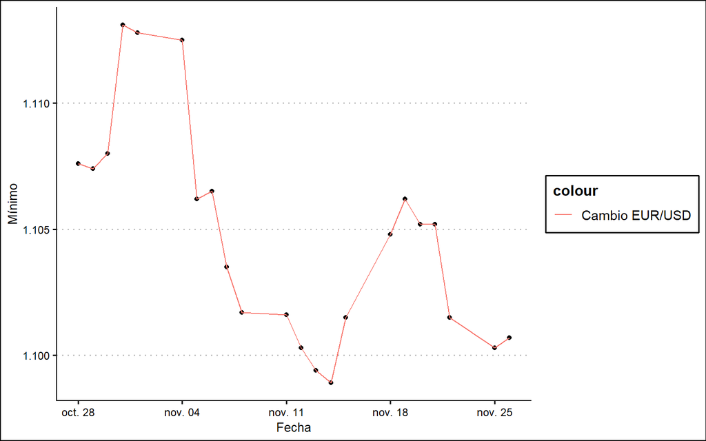

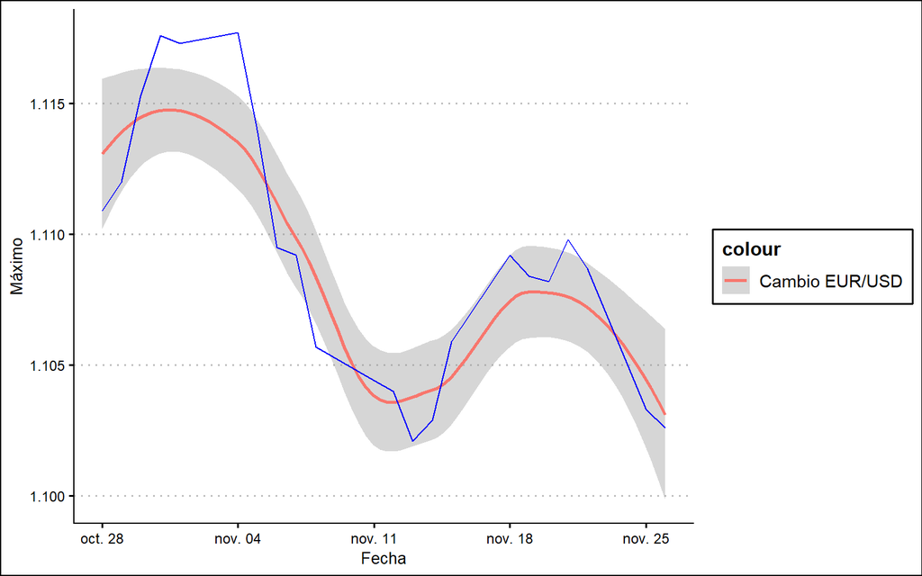

## Gráfico dinámico

Por último, el gráfico dinámico muestra de nuevo la evolución del mínimo respecto a los días, sabiendo que el tipo de cambio es el valor de una divisa en función de la otra, en este caso la divisa base es el euro, por lo que se indica el valor mínimo de 1 EUR respecto al dolar estadounidense. Al observar este gráfico, se puede observar que el valor más alto del mínimo coincide en la misma fecha que el valor más alto del máximo que se puede ver en el gráfico anterior y coincide con finales de octubre/ principios de noviembre.

[interactive chart not shown]

Belén Andrea de la Fuente Rodríguez